# 1 Data Preparation

**1.1 Merge data from each month into one CSV and read in updated DataFrame**

```python
#Import os module
import os

#Import pandas library
import pandas as pd
```

```python
#define the directory path where all the files are located
directory_path="Sales Analysis 2019/"
```

```python
#List all the files that are in the "Sales Analysis 2019" directory in the form of list
file_list=os.listdir(directory_path)
file_list     #either it will be .csv or .docx files, it display all the files
```

```
['Sales_December_2019.csv',
 'Sales_April_2019.csv',
 'Sales_February_2019.csv',
 'Sales_March_2019.csv',
 'Sales_August_2019.csv',
 'Sales_May_2019.csv',
 'Sales_November_2019.csv',
 'Sales_October_2019.csv',
 'Sales_January_2019.csv',
 'iugigigiguuggg.docx',
 'Sales_September_2019.csv',
 'Sales_July_2019.csv',
 'Sales_June_2019.csv']
```

```python
#Filter out non-CSV files  i.e only .CSV file is added
#Create an empty list named as csv_files
csv_files_2019=[]
for file in file_list: # for loop in the file_list
    if file.endswith('.csv'):  #search for the .csv extension
        csv_files_2019.append(file) #add the .CSV file(s) in csv_files list
csv_files_2019
```

```
['Sales_December_2019.csv',
 'Sales_April_2019.csv',
 'Sales_February_2019.csv',
 'Sales_March_2019.csv',
 'Sales_August_2019.csv',
 'Sales_May_2019.csv',
 'Sales_November_2019.csv',
 'Sales_October_2019.csv',
 'Sales_January_2019.csv',
 'Sales_September_2019.csv',
 'Sales_July_2019.csv',
 'Sales_June_2019.csv']
```

```python
#Create an empty DataFrame "merged_data_12Months_2019" to store all the 12 months data
merged_data_12Months_2019=pd.DataFrame()
for file in csv_files_2019: #for loop in the csv_files
    file_path=os.path.join(directory_path,file)  #Eg Sales Analysis 2019/Sales_January_2019
    data=pd.read_csv(file_path)  #Retrive the data from CSV files
    #Concatination of heavy lifting files
    merged_data_12Months_2019=pd.concat([merged_data_12Months_2019,data], ignore_index=True)
merged_data_12Months_2019
```

|  | Order ID | Product | Quantity Ordered | Price Each | Order Date | Purchase Address |
| --- | --- | --- | --- | --- | --- | --- |
| 0 | 295665.0 | Macbook Pro Laptop | 1.0 | 1700.00 | 12/30/2019 0:01 | 136 Church St, New York City, NY 10001 |
| 1 | 295666.0 | LG Washing Machine | 1.0 | 600.00 | 12/29/2019 7:03 | 562 2nd St, New York City, NY 10001 |
| 2 | 295667.0 | USB-C Charging Cable | 1.0 | 11.95 | 12/12/2019 18:21 | 277 Main St, New York City, NY 10001 |
| 3 | 295668.0 | 27in FHD Monitor | 1.0 | 149.99 | 12/22/2019 15:13 | 410 6th St, San Francisco, CA 94016 |
| 4 | 295669.0 | USB-C Charging Cable | 1.0 | 11.95 | 12/18/2019 12:38 | 43 Hill St, Atlanta, GA 30301 |
| ... | ... | ... | ... | ... | ... | ... |
| 186845 | 222905.0 | AAA Batteries (4-pack) | 1.0 | 2.99 | 6/7/2019 19:02 | 795 Pine St, Boston, MA 02215 |
| 186846 | 222906.0 | 27in FHD Monitor | 1.0 | 149.99 | 6/1/2019 19:29 | 495 North St, New York City, NY 10001 |
| 186847 | 222907.0 | USB-C Charging Cable | 1.0 | 11.95 | 6/22/2019 18:57 | 319 Ridge St, San Francisco, CA 94016 |
| 186848 | 222908.0 | USB-C Charging Cable | 1.0 | 11.95 | 6/26/2019 18:35 | 916 Main St, San Francisco, CA 94016 |
| 186849 | 222909.0 | AAA Batteries (4-pack) | 1.0 | 2.99 | 6/25/2019 14:33 | 209 11th St, Atlanta, GA 30301 |

186850 rows × 6 columns

```python
'''check if "merged_data_12Months_2019.csv" exists or not
if exists run if statement. if not then run else statement'''

if os.path.exists('merged_data_12Months_2019.csv'):
    print("merged_data_12Months_2019.csv already exists !!!")
else:

    #Export and save merged_data_12Months_2019 DataFrame to a CSV file named "merged_data_12Months_2019.csv"
    merged_data_12Months_2019.to_csv('merged_data_12Months_2019.csv', index=False) #ignore index
    print("Merged data of 12 months saved to merged_data_12Months_2019.csv")
```

```
merged_data_12Months_2019.csv already exists !!!
```

**1.2 Remove the NaN missing values from the updated dataframe**

*Checking missing vallues*

```python
#isna() function to detect missing values
NaNdf=merged_data_12Months_2019.isna()

#view 258 rows sample of Dataframe
NaNdf.head(258)
```

|  | Order ID | Product | Quantity Ordered | Price Each | Order Date | Purchase Address |
| --- | --- | --- | --- | --- | --- | --- |
| 0 | False | False | False | False | False | False |
| 1 | False | False | False | False | False | False |
| 2 | False | False | False | False | False | False |
| 3 | False | False | False | False | False | False |
| 4 | False | False | False | False | False | False |
| ... | ... | ... | ... | ... | ... | ... |
| 253 | False | False | False | False | False | False |
| 254 | True | True | True | True | True | True |
| 255 | False | False | False | False | False | False |
| 256 | False | False | False | False | False | False |
| 257 | False | False | False | False | False | False |

258 rows × 6 columns

*Droping missing values*

```python
#remove row(s) from a Dataframe
merged_data_12Months_2019=merged_data_12Months_2019.dropna()

#View 258 rows sample of Dataframe
merged_data_12Months_2019.head(258)
```

|  | Order ID | Product | Quantity Ordered | Price Each | Order Date | Purchase Address |
| --- | --- | --- | --- | --- | --- | --- |
| 0 | 295665.0 | Macbook Pro Laptop | 1.0 | 1700.00 | 12/30/2019 0:01 | 136 Church St, New York City, NY 10001 |
| 1 | 295666.0 | LG Washing Machine | 1.0 | 600.00 | 12/29/2019 7:03 | 562 2nd St, New York City, NY 10001 |
| 2 | 295667.0 | USB-C Charging Cable | 1.0 | 11.95 | 12/12/2019 18:21 | 277 Main St, New York City, NY 10001 |
| 3 | 295668.0 | 27in FHD Monitor | 1.0 | 149.99 | 12/22/2019 15:13 | 410 6th St, San Francisco, CA 94016 |
| 4 | 295669.0 | USB-C Charging Cable | 1.0 | 11.95 | 12/18/2019 12:38 | 43 Hill St, Atlanta, GA 30301 |
| ... | ... | ... | ... | ... | ... | ... |
| 253 | 295901.0 | 20in Monitor | 1.0 | 109.99 | 12/5/2019 20:02 | 67 12th St, San Francisco, CA 94016 |
| 255 | 295902.0 | AA Batteries (4-pack) | 2.0 | 3.84 | 12/26/2019 21:54 | 160 Maple St, Austin, TX 73301 |
| 256 | 295903.0 | AA Batteries (4-pack) | 1.0 | 3.84 | 12/21/2019 13:40 | 337 12th St, Dallas, TX 75001 |
| 257 | 295904.0 | Wired Headphones | 1.0 | 11.99 | 12/19/2019 17:30 | 647 Wilson St, Atlanta, GA 30301 |
| 258 | 295905.0 | AA Batteries (4-pack) | 2.0 | 3.84 | 12/6/2019 23:48 | 345 Walnut St, Los Angeles, CA 90001 |

258 rows × 6 columns

**1.3 Convert "Quantity Ordered" and "Price Each" to numeric**

*Show the datatypes of columns*

```python
print(merged_data_12Months_2019.dtypes)
```

```
Order ID            float64
Product              object
Quantity Ordered    float64
Price Each          float64
Order Date           object
Purchase Address     object
dtype: object
```

*Converting "Quantity Ordered" and "Price Each" columns to numeric*

```python
#Using dictionary to convert the data type of  specific colums
convert_dict={'Quantity Ordered': int,
              'Price Each': float
             }

#assign convert_dict as parameter.
merged_data_12Months_2019=merged_data_12Months_2019.astype(convert_dict)
print(merged_data_12Months_2019.dtypes)
```

```
Order ID            float64
Product              object
Quantity Ordered      int64
Price Each          float64
Order Date           object
Purchase Address     object
dtype: object
```

**1.4. Create a new column named Month from Ordered Date of updated dataframe and convert it to integer as data type.**

```python
#Display all the columns
merged_data_12Months_2019.columns
```

```
Index(['Order ID', 'Product', 'Quantity Ordered', 'Price Each', 'Order Date',
       'Purchase Address'],
      dtype='object')
```

```python
#Convert "Order Date" to datetime as datatype
merged_data_12Months_2019['Order Date']=pd.to_datetime(merged_data_12Months_2019['Order Date'])

#Extract month from "Ordered Date"
merged_data_12Months_2019['Month']=merged_data_12Months_2019['Order Date'].dt.month
#convert "Month" to integer
merged_data_12Months_2019['Month']=merged_data_12Months_2019['Month'].astype(int)

print(merged_data_12Months_2019.dtypes)
merged_data_12Months_2019
```

```
Order ID                   float64
Product                     object
Quantity Ordered             int64
Price Each                 float64
Order Date          datetime64[ns]
Purchase Address            object
Month                        int64
dtype: object
```

|  | Order ID | Product | Quantity Ordered | Price Each | Order Date | Purchase Address | Month |
| --- | --- | --- | --- | --- | --- | --- | --- |
| 0 | 295665.0 | Macbook Pro Laptop | 1 | 1700.00 | 2019-12-30 00:01:00 | 136 Church St, New York City, NY 10001 | 12 |
| 1 | 295666.0 | LG Washing Machine | 1 | 600.00 | 2019-12-29 07:03:00 | 562 2nd St, New York City, NY 10001 | 12 |
| 2 | 295667.0 | USB-C Charging Cable | 1 | 11.95 | 2019-12-12 18:21:00 | 277 Main St, New York City, NY 10001 | 12 |
| 3 | 295668.0 | 27in FHD Monitor | 1 | 149.99 | 2019-12-22 15:13:00 | 410 6th St, San Francisco, CA 94016 | 12 |
| 4 | 295669.0 | USB-C Charging Cable | 1 | 11.95 | 2019-12-18 12:38:00 | 43 Hill St, Atlanta, GA 30301 | 12 |
| ... | ... | ... | ... | ... | ... | ... | ... |
| 186845 | 222905.0 | AAA Batteries (4-pack) | 1 | 2.99 | 2019-06-07 19:02:00 | 795 Pine St, Boston, MA 02215 | 6 |
| 186846 | 222906.0 | 27in FHD Monitor | 1 | 149.99 | 2019-06-01 19:29:00 | 495 North St, New York City, NY 10001 | 6 |
| 186847 | 222907.0 | USB-C Charging Cable | 1 | 11.95 | 2019-06-22 18:57:00 | 319 Ridge St, San Francisco, CA 94016 | 6 |
| 186848 | 222908.0 | USB-C Charging Cable | 1 | 11.95 | 2019-06-26 18:35:00 | 916 Main St, San Francisco, CA 94016 | 6 |
| 186849 | 222909.0 | AAA Batteries (4-pack) | 1 | 2.99 | 2019-06-25 14:33:00 | 209 11th St, Atlanta, GA 30301 | 6 |

185950 rows × 7 columns

**1.5 Create a new column named City from Purchase Address based on the value in updated dataframe.**

```python
#Create an empty list to store extracted city names from "Purchase Address"
city_list=[]

#Loop through each address in the "Purchase Address" column
for address in merged_data_12Months_2019['Purchase Address']:

    #Split the address by comma and extract the element at the index 1 i.e city name
    city=address.split(',')[1]

    #add the extracted city name in city_list
    city_list.append(city)
#Assign the city_list to a new "City" column in the dataframe
merged_data_12Months_2019['City']=city_list
merged_data_12Months_2019
```

|  | Order ID | Product | Quantity Ordered | Price Each | Order Date | Purchase Address | Month | City |
| --- | --- | --- | --- | --- | --- | --- | --- | --- |
| 0 | 295665.0 | Macbook Pro Laptop | 1 | 1700.00 | 2019-12-30 00:01:00 | 136 Church St, New York City, NY 10001 | 12 | New York City |
| 1 | 295666.0 | LG Washing Machine | 1 | 600.00 | 2019-12-29 07:03:00 | 562 2nd St, New York City, NY 10001 | 12 | New York City |
| 2 | 295667.0 | USB-C Charging Cable | 1 | 11.95 | 2019-12-12 18:21:00 | 277 Main St, New York City, NY 10001 | 12 | New York City |
| 3 | 295668.0 | 27in FHD Monitor | 1 | 149.99 | 2019-12-22 15:13:00 | 410 6th St, San Francisco, CA 94016 | 12 | San Francisco |
| 4 | 295669.0 | USB-C Charging Cable | 1 | 11.95 | 2019-12-18 12:38:00 | 43 Hill St, Atlanta, GA 30301 | 12 | Atlanta |
| ... | ... | ... | ... | ... | ... | ... | ... | ... |
| 186845 | 222905.0 | AAA Batteries (4-pack) | 1 | 2.99 | 2019-06-07 19:02:00 | 795 Pine St, Boston, MA 02215 | 6 | Boston |
| 186846 | 222906.0 | 27in FHD Monitor | 1 | 149.99 | 2019-06-01 19:29:00 | 495 North St, New York City, NY 10001 | 6 | New York City |
| 186847 | 222907.0 | USB-C Charging Cable | 1 | 11.95 | 2019-06-22 18:57:00 | 319 Ridge St, San Francisco, CA 94016 | 6 | San Francisco |
| 186848 | 222908.0 | USB-C Charging Cable | 1 | 11.95 | 2019-06-26 18:35:00 | 916 Main St, San Francisco, CA 94016 | 6 | San Francisco |
| 186849 | 222909.0 | AAA Batteries (4-pack) | 1 | 2.99 | 2019-06-25 14:33:00 | 209 11th St, Atlanta, GA 30301 | 6 | Atlanta |

185950 rows × 8 columns

# 2 Data Analysis

**2.1 Write a Python program to show summary statistics of sum, mean, standard deviation, skewness, and kurtosis of any chosen variable**

```python
#Assigning 'Quantity Ordered' column values in a quantityOrdered variable
quantityOrdered=merged_data_12Months_2019['Quantity Ordered']
#type(quantityOrder)   #Series

#sum of all data in quantiyOrdered Series
print("The sum of quantity ordered is: ",quantityOrdered.sum())

#calculates the mean(average) of quantityOrdered Series
print("The mean of quantity ordered is: ",quantityOrdered.mean())

#Calculates the standard deviation of quantityOrdered Series
print("The Standard Deviation of quantity ordered is: ",quantityOrdered.std())

print("The skewness of quantity ordered is: ",quantityOrdered.skew())

print("The kurtosis of quantity ordered is: ",quantityOrdered.kurtosis())
```

```
The sum of quantity ordered is:  209079
The mean of quantity ordered is:  1.1243828986286637
The Standard Deviation of quantity ordered is:  0.44279262402848835
The skewness of quantity ordered is:  4.833164172577953
The kurtosis of quantity ordered is:  31.820488920275366
```

**2.2 Write a Python program to calculate and show correlation of all variables.**

```python
# Calculate the correlation matrix of all variables in the DataFrame
correlation_matrix = merged_data_12Months_2019.corr()

# Print the correlation matrix
print("Correlation Matrix:")
print(correlation_matrix)
```

```
Correlation Matrix:
                  Order ID  Quantity Ordered  Price Each     Month
Order ID          1.000000          0.000702   -0.002857  0.993063
Quantity Ordered  0.000702          1.000000   -0.148272  0.000791
Price Each       -0.002857         -0.148272    1.000000 -0.003375
Month             0.993063          0.000791   -0.003375  1.000000
```

# 3 Data Exploration

**3.1 Which Month has the best sales? and how much was the earning in that month? Make a bar graph of sales as well.**

```python
#Add 'Total Sales' column
#Calculate total sales of each day
# Since, the right side is not visible so the rest of code is... * merged_data_12Months_2019['Price Each']
merged_data_12Months_2019['Total Sales']=merged_data_12Months_2019['Quantity Ordered']*merged_data_12Months_2019['Price Each']
merged_data_12Months_2019.head()
```

|  | Order ID | Product | Quantity Ordered | Price Each | Order Date | Purchase Address | Month | City | Total Sales |
| --- | --- | --- | --- | --- | --- | --- | --- | --- | --- |
| 0 | 295665.0 | Macbook Pro Laptop | 1 | 1700.00 | 2019-12-30 00:01:00 | 136 Church St, New York City, NY 10001 | 12 | New York City | 1700.00 |
| 1 | 295666.0 | LG Washing Machine | 1 | 600.00 | 2019-12-29 07:03:00 | 562 2nd St, New York City, NY 10001 | 12 | New York City | 600.00 |
| 2 | 295667.0 | USB-C Charging Cable | 1 | 11.95 | 2019-12-12 18:21:00 | 277 Main St, New York City, NY 10001 | 12 | New York City | 11.95 |
| 3 | 295668.0 | 27in FHD Monitor | 1 | 149.99 | 2019-12-22 15:13:00 | 410 6th St, San Francisco, CA 94016 | 12 | San Francisco | 149.99 |
| 4 | 295669.0 | USB-C Charging Cable | 1 | 11.95 | 2019-12-18 12:38:00 | 43 Hill St, Atlanta, GA 30301 | 12 | Atlanta | 11.95 |

```python
#group by months and add the sales of each month
monthly_sales=merged_data_12Months_2019.groupby('Month', as_index=False).sum()
monthly_sales
```

|  | Month | Order ID | Quantity Ordered | Price Each | Total Sales |
| --- | --- | --- | --- | --- | --- |
| 0 | 1 | 1.421631e+09 | 10903 | 1811768.38 | 1822256.73 |
| 1 | 2 | 1.871053e+09 | 13449 | 2188884.72 | 2202022.42 |
| 2 | 3 | 2.564811e+09 | 17005 | 2791207.83 | 2807100.38 |
| 3 | 4 | 3.387347e+09 | 20558 | 3367671.02 | 3390670.24 |
| 4 | 5 | 3.345872e+09 | 18667 | 3135125.13 | 3152606.75 |
| 5 | 6 | 2.932976e+09 | 15253 | 2562025.61 | 2577802.26 |
| 6 | 7 | 3.284140e+09 | 16072 | 2632539.56 | 2647775.76 |
| 7 | 8 | 2.899374e+09 | 13448 | 2230345.42 | 2244467.88 |
| 8 | 9 | 2.948727e+09 | 13109 | 2084992.09 | 2097560.13 |
| 9 | 10 | 5.457110e+09 | 22703 | 3715554.83 | 3736726.88 |
| 10 | 11 | 5.047203e+09 | 19798 | 3180600.68 | 3199603.20 |
| 11 | 12 | 7.685905e+09 | 28114 | 4588415.41 | 4613443.34 |

```python
#find the max value in 'Total Sales' Column and get the entire column
max_sales=monthly_sales.loc[monthly_sales['Total Sales'].idxmax()]
max_sales
```

```
Month               1.200000e+01
Order ID            7.685905e+09
Quantity Ordered    2.811400e+04
Price Each          4.588415e+06
Total Sales         4.613443e+06
Name: 11, dtype: float64
```

```python
import matplotlib.pyplot as plt
```

*Visualizing sales in different months*

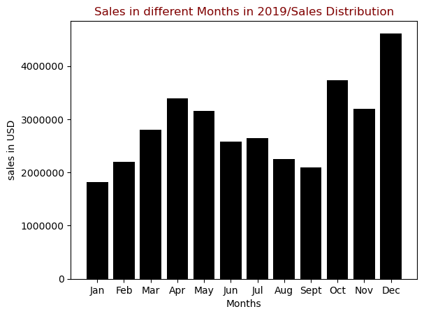

```python
months=['Jan','Feb','Mar','Apr','May','Jun','Jul','Aug','Sept','Oct','Nov','Dec'] #for x axis
results=merged_data_12Months_2019.groupby('Month').sum()
sales=results['Total Sales']

#create a bar graph
plt.bar(months,sales, color="black")

#Add labels and title
plt.xlabel("Months")
plt.ylabel("sales in USD")
plt.title("Sales in different Months in 2019/Sales Distribution", color="maroon")

#Change the SclarFormatter of y axis
plt.ticklabel_format(axis='y',style='plain')  # removing le6 from bar graph

#show the graph
plt.show()
```

**3.2 Which city has sold the highest product?**

```python
#group by city and add the values based on group
city_sales=merged_data_12Months_2019.groupby('City',as_index=False)[['Quantity Ordered','Total Sales']].sum()
city_sales
```

|  | City | Quantity Ordered | Total Sales |
| --- | --- | --- | --- |
| 0 | Atlanta | 16602 | 2795498.58 |
| 1 | Austin | 11153 | 1819581.75 |
| 2 | Boston | 22528 | 3661642.01 |
| 3 | Dallas | 16730 | 2767975.40 |
| 4 | Los Angeles | 33289 | 5452570.80 |
| 5 | New York City | 27932 | 4664317.43 |
| 6 | Portland | 14053 | 2320490.61 |
| 7 | San Francisco | 50239 | 8262203.91 |
| 8 | Seattle | 16553 | 2747755.48 |

```python
#Filter the row with the maximum sales
highest_sales=city_sales[city_sales['Total Sales']==city_sales['Total Sales'].max()]
highest_sales
```

|  | City | Quantity Ordered | Total Sales |
| --- | --- | --- | --- |
| 7 | San Francisco | 50239 | 8262203.91 |

**3.3 Which product was sold the most in overall? Illustrate it through bar graph.**

```python
#group by product and add the each values
product_sales=merged_data_12Months_2019.groupby('Product',as_index=False)[['Quantity Ordered','Total Sales']].sum()
product_sales
```

|  | Product | Quantity Ordered | Total Sales |
| --- | --- | --- | --- |
| 0 | 20in Monitor | 4129 | 454148.71 |
| 1 | 27in 4K Gaming Monitor | 6244 | 2435097.56 |
| 2 | 27in FHD Monitor | 7550 | 1132424.50 |
| 3 | 34in Ultrawide Monitor | 6199 | 2355558.01 |
| 4 | AA Batteries (4-pack) | 27635 | 106118.40 |
| 5 | AAA Batteries (4-pack) | 31017 | 92740.83 |
| 6 | Apple Airpods Headphones | 15661 | 2349150.00 |
| 7 | Bose SoundSport Headphones | 13457 | 1345565.43 |
| 8 | Flatscreen TV | 4819 | 1445700.00 |
| 9 | Google Phone | 5532 | 3319200.00 |
| 10 | LG Dryer | 646 | 387600.00 |
| 11 | LG Washing Machine | 666 | 399600.00 |
| 12 | Lightning Charging Cable | 23217 | 347094.15 |
| 13 | Macbook Pro Laptop | 4728 | 8037600.00 |
| 14 | ThinkPad Laptop | 4130 | 4129958.70 |
| 15 | USB-C Charging Cable | 23975 | 286501.25 |
| 16 | Vareebadd Phone | 2068 | 827200.00 |
| 17 | Wired Headphones | 20557 | 246478.43 |
| 18 | iPhone | 6849 | 4794300.00 |

```python
#Filter the row with the maximum sales
highest_sales_product=product_sales[product_sales['Quantity Ordered']==product_sales['Quantity Ordered'].max()]
highest_sales_product
```

|  | Product | Quantity Ordered | Total Sales |
| --- | --- | --- | --- |
| 5 | AAA Batteries (4-pack) | 31017 | 92740.83 |

*Visualizing the result in bar graph*

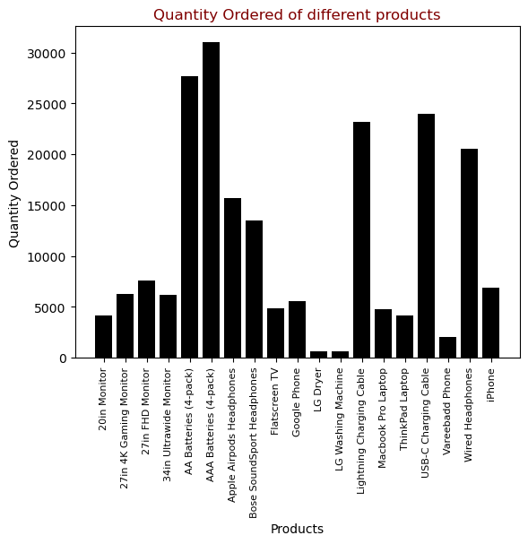

```python
products=product_sales['Product']
#quantity=product_sales['Quanity Ordered']
quantity_ordered=product_sales['Quantity Ordered']

plt.bar(products,quantity_ordered, color="black")

plt.xlabel("Products")
plt.ylabel("Quantity Ordered")
plt.title("Quantity Ordered of different products",color="maroon")

plt.ticklabel_format(axis='y',style='plain')
plt.xticks(products,rotation='vertical', size=8)

plt.show()
```

**3.4 Write a Python program to show histogram plot of any chosen variables. Use proper labels in the graph.**

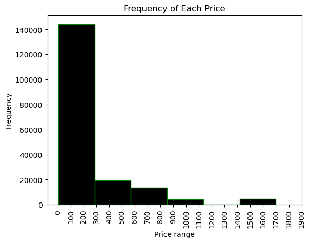

```python
#create histogram and assign "Price Each" column values of updated DataFrame
plt.hist(merged_data_12Months_2019['Price Each'],color="black", edgecolor='green',bins=6)


plt.xticks(range(0,2000,100), rotation='vertical') #labels ranging from 0 to 2000 with an interval of 100

#Set labels and title
plt.xlabel('Price range')
plt.ylabel('Frequency')
plt.title('Frequency of Each Price')

#Display histogram.
plt.show()
```